# UCI Online Shoppers Purchasing Intention Analysis

hbmaclean

2025-09-02

# 1 Introduction

I chose this dataset having worked in eCommerce. Below is a description of the data from [UCI](https://archive.ics.uci.edu/dataset/468/online+shoppers+purchasing+intention+dataset):

> The dataset consists of feature vectors belonging to 12,330 sessions. The dataset was formed so that each session would belong to a different user in a 1-year period to avoid any tendency to a specific campaign, special day, user profile, or period.

> The dataset consists of 10 numerical and 8 categorical attributes. The ‘Revenue’ attribute can be used as the class label.

> “Administrative”, “Administrative Duration”, “Informational”, “Informational Duration”, “Product Related” and “Product Related Duration” represent the number of different types of pages visited by the visitor in that session and total time spent in each of these page categories. The values of these features are derived from the URL information of the pages visited by the user and updated in real time when a user takes an action, e.g. moving from one page to another.

> The “Bounce Rate”, “Exit Rate” and “Page Value” features represent the metrics measured by “Google Analytics” for each page in the e-commerce site. The value of “Bounce Rate” feature for a web page refers to the percentage of visitors who enter the site from that page and then leave (“bounce”) without triggering any other requests to the analytics server during that session. The value of “Exit Rate” feature for a specific web page is calculated as for all pageviews to the page, the percentage that were the last in the session. The “Page Value” feature represents the average value for a web page that a user visited before completing an e-commerce transaction.

> The “Special Day” feature indicates the closeness of the site visiting time to a specific special day (e.g. Mother’s Day, Valentine’s Day) in which the sessions are more likely to be finalized with transaction. The value of this attribute is determined by considering the dynamics of e-commerce such as the duration between the order date and delivery date. For example, for Valentina’s day, this value takes a nonzero value between February 2 and February 12, zero before and after this date unless it is close to another special day, and its maximum value of 1 on February 8.

> The dataset also includes operating system, browser, region, traffic type, visitor type as returning or new visitor, a Boolean value indicating whether the date of the visit is weekend, and month of the year.

# 2 Installing Packages

```r
library(data.frame.X)
install_packages(c(
    'caret', 'stringr', 'readr', 'dplyr', 'kableExtra', 'DT', 'gridExtra',
    'ranger', 'randomForest', 'naivebayes', 'nnet', 'tibble', 'missMethods',
    'varhandle', 'devtools'
))

install_github('munoztd0/reprtree')
eval(substitute(library(pkg), list(pkg='reprtree')))
library(reprtree)

set.seed(234)
```

# 3 Data Creation

This downloads the [zip](https://archive.ics.uci.edu/dataset/73/mushroom), extracts the data file, reads and parses the lines into a `data.frame` and adds column names.

```r
# Download online+shoppers+purchasing+intention+dataset.zip from UCI.edu
# and render it as a data.frame
fetch_data <- function(verbose = FALSE) {
    options(timeout = 120)
    tmp   <- tempfile()
    zip   <- paste0(
        'https://archive.ics.uci.edu',
        '/static/public/468/online+shoppers+purchasing+intention+dataset.zip'
    )
    download.file(zip, tmp, quiet = !verbose)
    data <- read_csv(unz(tmp, 'online_shoppers_intention.csv'))

    # Here I abbreviate some of the lengthy names as given
    colnames(data) <- c(
        'Admin', 'AdminDur', 'Info', 'InfoDur', 'Prod', 'ProdDur',
        'BounceRate', 'ExitRate', 'PageVal', 'SpecialDay', 'Month',
        'OS', 'Browser', 'Region', 'TrafficType', 'VisitorType',
        'Weekend', 'Revenue'
    )
    return(data)
}

shoppers_df <- fetch_data()
shoppers_df |>
    slice_sample(n = 10) |>
    mutate(across(where(is.numeric), ~ round(.x, 1))) |>
    datatable(
        rownames = FALSE,
        options  = list(
            dom        = 't',
            scrollX    = TRUE,
            pageLength = nrow(.data)
        )
    )
```

| Admin | AdminDur | Info | InfoDur | Prod | ProdDur | BounceRate | ExitRate | PageVal | SpecialDay | Month | OS | Browser | Region | TrafficType | VisitorType | Weekend | Revenue |
| --- | --- | --- | --- | --- | --- | --- | --- | --- | --- | --- | --- | --- | --- | --- | --- | --- | --- |
| 1 | 6 | 0 | 0 | 6 | 45.5 | 0.1 | 0.1 | 0 | 0 | Mar | 1 | 1 | 3 | 3 | Returning_Visitor | False | False |
| 3 | 18 | 0 | 0 | 14 | 411.5 | 0 | 0 | 0 | 0 | Mar | 2 | 2 | 8 | 2 | Returning_Visitor | False | False |
| 5 | 120 | 1 | 0 | 27 | 1583.6 | 0 | 0 | 39.6 | 0 | Mar | 2 | 2 | 4 | 2 | Returning_Visitor | False | False |
| 0 | 0 | 0 | 0 | 6 | 50 | 0 | 0.1 | 0 | 0 | May | 2 | 5 | 6 | 4 | Returning_Visitor | False | False |
| 0 | 0 | 0 | 0 | 16 | 977.1 | 0 | 0 | 0 | 0 | Dec | 2 | 2 | 1 | 2 | Returning_Visitor | True | False |
| 2 | 57 | 0 | 0 | 15 | 772.9 | 0 | 0 | 0 | 0 | Nov | 3 | 2 | 3 | 13 | Returning_Visitor | False | False |
| 4 | 146 | 0 | 0 | 14 | 879.5 | 0 | 0 | 0 | 0 | Dec | 2 | 5 | 4 | 2 | New_Visitor | True | False |
| 4 | 32.7 | 0 | 0 | 34 | 1379 | 0 | 0 | 18.5 | 0 | May | 3 | 2 | 1 | 4 | Returning_Visitor | True | True |
| 2 | 7 | 0 | 0 | 21 | 468 | 0 | 0.1 | 0 | 0 | May | 2 | 5 | 1 | 3 | Returning_Visitor | False | False |
| 0 | 0 | 0 | 0 | 15 | 183.8 | 0.1 | 0.1 | 0 | 0.8 | May | 3 | 2 | 1 | 3 | Returning_Visitor | False | False |

## 3.1 Making Numeric

Making the few non-numeric columns numeric which will simplify analysis. Month, obviously, can be converted to 1:12. The two logical columns, Weekend and Revenue, can be represented as 1:0. VisitorType can be represented by 1:3 for its three distinct values:

```r
table(shoppers_df$VisitorType) |>
    kable(col.names = c('VisitorType', 'Frequency')) |>
    kable_styling(full_width = FALSE, position = 'left')
```

| VisitorType | Frequency |
| --- | --- |
| New_Visitor | 1694 |
| Other | 85 |
| Returning_Visitor | 10551 |

```r
shoppers_df <- shoppers_df |>
    mutate(
        Month       = coalesce(match(Month, month.abb), match(Month,month.name)),
        VisitorType = match(VisitorType, as.vector(unique(VisitorType))),
        across(where(is.logical), ~ as.integer(.x))
    )
```

## 3.2 Partitioning

```r
index     <- createDataPartition(y = shoppers_df$Revenue, times = 1, p = 0.5, list = FALSE)
train_df  <- shoppers_df[index,]
test_df   <- shoppers_df[-index,]
```

# 4 Initial Analysis

## 4.1 Class Distribution

85%/15% - may need to pick a model that supports class weights.

```r
round(prop.table(table(shoppers_df$Revenue)),2) |>
    kable(col.names = c('Revenue', 'Frequency')) |>
    kable_styling(full_width = FALSE, position = 'left')
```

| Revenue | Frequency |
| --- | --- |
| 0 | 0.85 |
| 1 | 0.15 |

## 4.2 Missing, Duplicate, and Outlying Values

There is a small portion of duplicate rows. In my last project, I found that removing duplicates crushed accuracy - so I will look to remove these experimentally later.

```r
any_NA_dup_outliers(shoppers_df, tabular = TRUE)
```

Missing, Duplicate, Outlying, and Extreme Values

| missing | duplicate | outlying | extreme |
| --- | --- | --- | --- |
| 0 | 125 | 36171 | 27360 |

There are *many* outliers and extreme values. I suspect most are expected due to the nature of the data.

```r
colSums(rstatix::is_outlier(shoppers_df |> as.matrix())) |>
    as.data.frame() |>
    tibble::rownames_to_column(var = 'Column') |>
    rename(Outliers = c(2)) |>
    arrange(desc(Outliers)) |>
    inner_join(
        round(colMeans(shoppers_df),2) |>
        as.data.frame() |>
        tibble::rownames_to_column(var = 'Column') |>
        rename(Mean = c(2)),
        by = 'Column'
    ) |>
    inner_join(
        round(apply(shoppers_df, 2, FUN = sd),2) |>
        as.data.frame() |>
        tibble::rownames_to_column(var = 'Column') |>
        rename(SD = c(2)),
        by = 'Column'
    ) |>
    kable() |>
    kable_styling(
        bootstrap_options = 'bordered',
        full_width        = FALSE,
        position          = 'left'
    )
```

| Column | Outliers | Mean | SD |
| --- | --- | --- | --- |
| ProdDur | 11488 | 1194.75 | 1913.67 |
| Prod | 8157 | 31.73 | 44.48 |
| AdminDur | 6054 | 80.82 | 176.78 |
| Month | 4725 | 7.65 | 3.39 |
| InfoDur | 2187 | 34.47 | 140.75 |
| PageVal | 1802 | 5.89 | 18.57 |
| TrafficType | 1266 | 4.07 | 4.03 |
| Admin | 404 | 2.32 | 3.32 |
| Browser | 77 | 2.36 | 1.72 |
| Info | 11 | 0.50 | 1.27 |
| BounceRate | 0 | 0.02 | 0.05 |
| ExitRate | 0 | 0.04 | 0.05 |
| SpecialDay | 0 | 0.06 | 0.20 |
| OS | 0 | 2.12 | 0.91 |
| Region | 0 | 3.15 | 2.40 |
| VisitorType | 0 | 1.15 | 0.38 |
| Weekend | 0 | 0.23 | 0.42 |
| Revenue | 0 | 0.15 | 0.36 |

From work experience, I also suspect that durations are susceptible to “cart abandonment” - shoppers leaving a session in a forgotten browser window/tab and eventually timing out.

Coupling the information above with the bar charts below, it is clear that product pages generally get lengthier looks - but also have extreme outliers (presumed abandonment); while admin- and info pages generally get brief looks - but also have outliers.

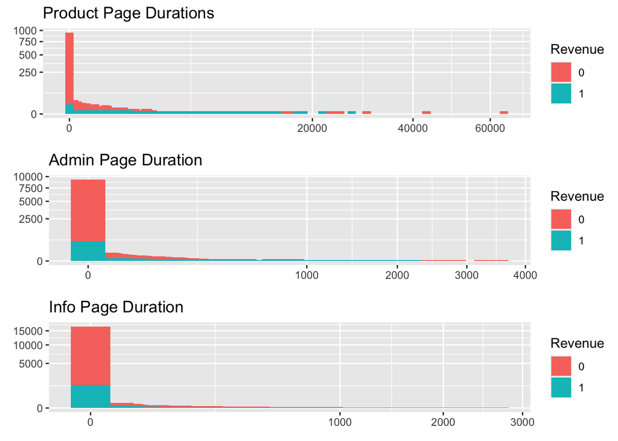

```r
common <- list(
    geom_bar(width = 5), scale_y_sqrt(), scale_x_sqrt(),
    labs(fill = 'Revenue', x = element_blank(), y = element_blank())
)
grid.arrange(
    shoppers_df |> ggplot(aes(ProdDur, fill = factor(Revenue))) +
        ggtitle('Product Page Durations') + common,
    shoppers_df |> ggplot(aes(AdminDur, fill = factor(Revenue))) +
        ggtitle('Admin Page Duration') + common,
    shoppers_df |> ggplot(aes(InfoDur, fill = factor(Revenue))) +
        ggtitle('Info Page Duration') + common,
    nrow = 3
)
```

Here is a second approach providing a similar look. Evidently, revenue is best with very brief cumulative page views; but continues for product page views up to about 15000 (ms, presumably.)

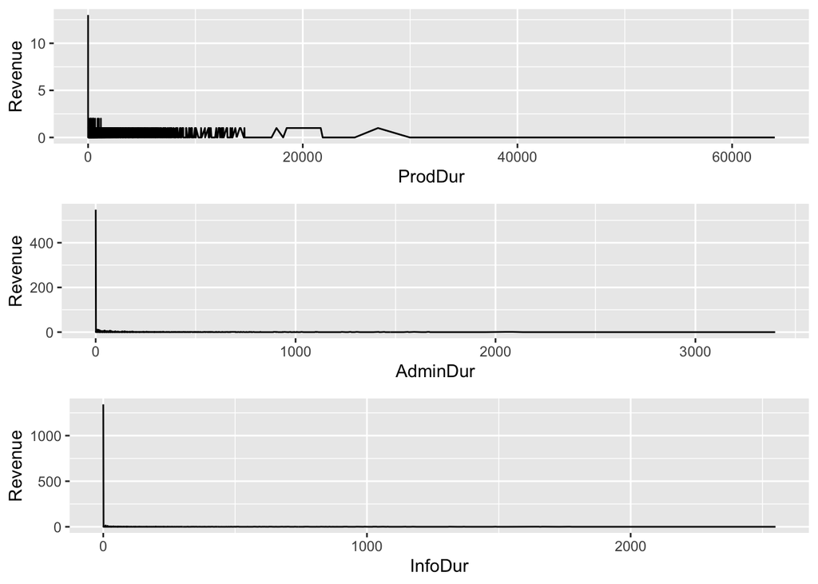

```r
grid.arrange(
    aggregate(shoppers_df, Revenue ~ ProdDur, sum) |>
        ggplot(aes(ProdDur, Revenue)) +
        geom_line(),
    aggregate(shoppers_df, Revenue ~ AdminDur, sum) |>
        ggplot(aes(AdminDur, Revenue)) +
        geom_line(),
    aggregate(shoppers_df, Revenue ~ InfoDur, sum) |>
        ggplot(aes(InfoDur, Revenue)) +
        geom_line(),
    nrow = 3
)
```

## 4.3 Near-Zero Variance

As expected, durations and rates are variable; while other columns have relatively few distinct values. None of the columns is considered to have near-zero variance, and thus `nzv` and `zv` are not worthwhile `preProcess` methods here.

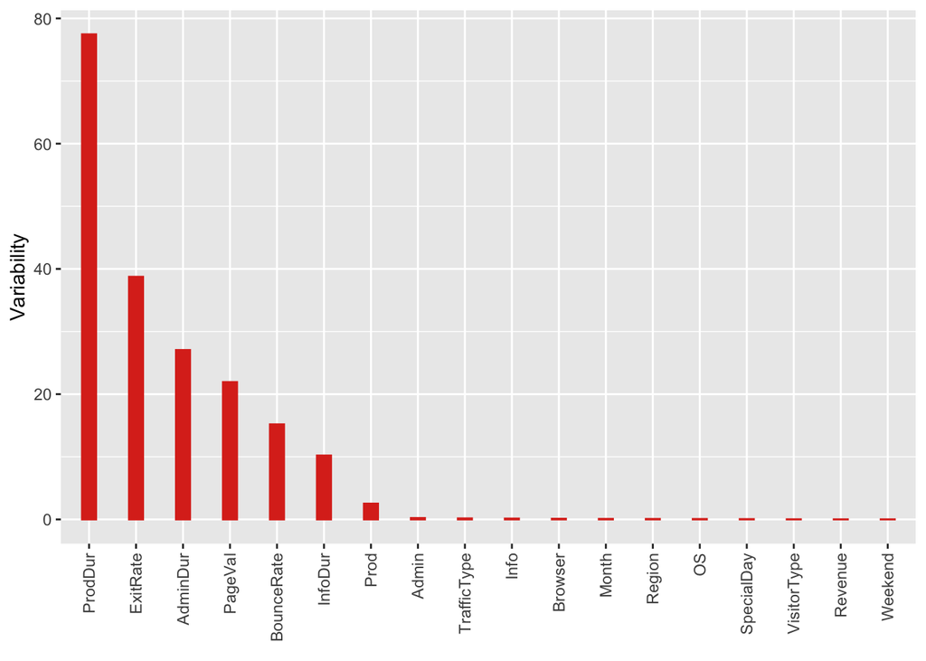

```r
nzv_plot(shoppers_df)
```

Related to `nearZeroVar`, `checkConditonalX` reports any predictor that is sparse conditioned on the levels of the outcome. Here, there is no such predictor, and thus `conditionalX` is not a worthwhile `preProcess` method here.

```r
checkConditionalX(shoppers_df |> select(-c(Revenue)), shoppers_df$Revenue)
```

```
## integer(0)
```

## 4.4 Correlation

Two pairs, `ExitRate` and `BounceRate`, and `Prod` and `ProdDur`, have *about* 90% correlation. (Note that correlation is rounded to one digit for legibility.) Perhaps one from each pair can be omitted.

`Browser`, `OS`, `Region`, and `Weekend`, and `TrafficType` to a lesser extent, have noticeably weak correlations and sparse representation due to high p-values. Perhaps one or more can be omitted.

It is also notable that `PageVal` has the largest correlation with `Revenue`.

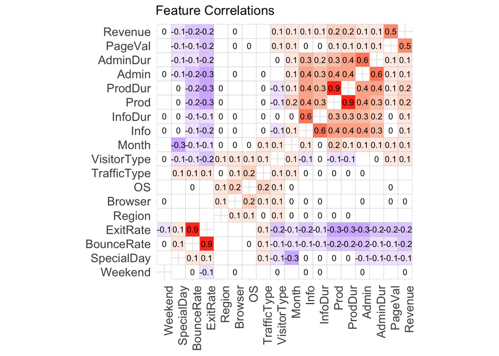

```r
corr_plot(shoppers_df, tl.srt = 90, digits = 1)
```

## 4.5 Principal Component Analysis

The fact that these plots are difficult to read indicates that the variance is spread widely and fairly evenly. `pca` does not look like a worthwhile `preProcess` method here.

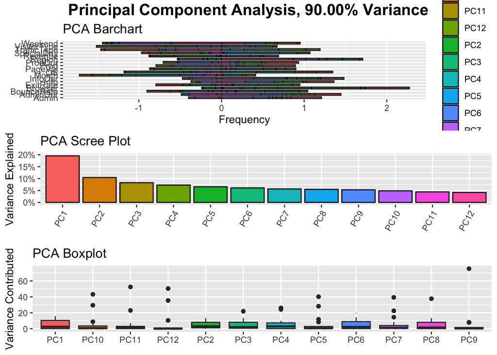

```r
pca_plot(shoppers_df, pct = .90)
```

But oh my! Later I learned that scale is disastrous here - causes `ranger` to always pick the negative class; and awhile after learning that, I realized that my `pca_plot` had `scale = TRUE` for `prcomp`. I’ve updated that to be optional, and… one PC expains 99% of the overall variance!

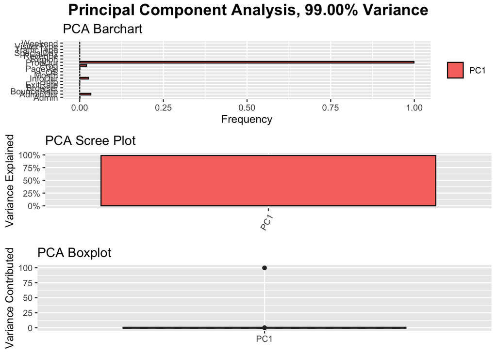

```r
pca_plot(shoppers_df, scale = FALSE, pct = .99)
```

Knowing that, I refer back to my coursework and its [Dimension Reduction](https://rafalab.dfci.harvard.edu/dsbook-part-2/highdim/dimension-reduction.html) section, and plot the distance matrix for the data (a subset of it, for performance reasons) versus the `prcomp` rotated data of the first PC.

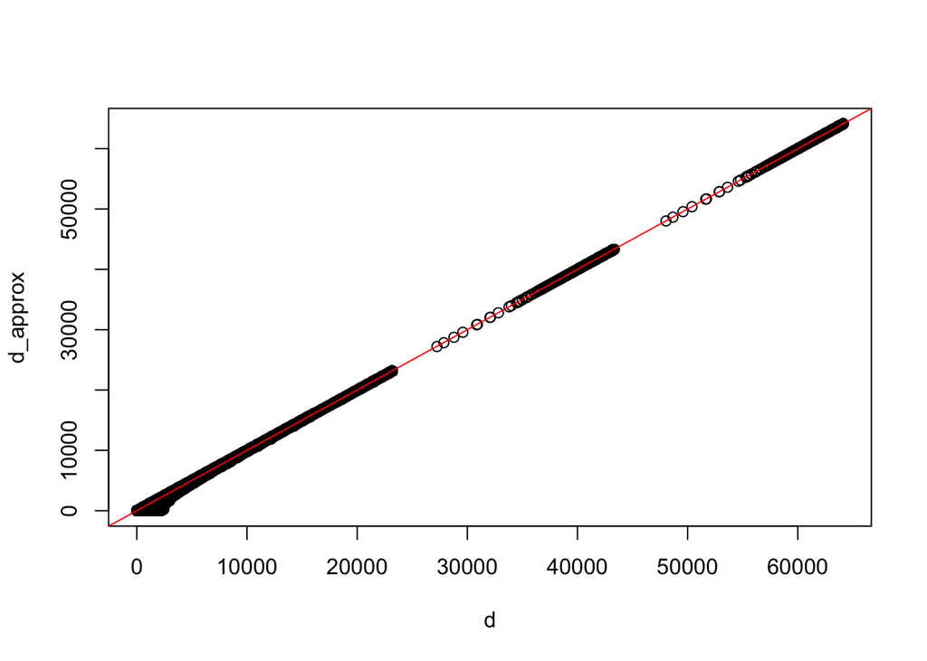

```r
x        <- as.matrix(shoppers_df |> slice_sample(prop = .20))
pca      <- prcomp(x)
d        <- dist(x)
d_approx <- dist(pca$x[, 1])
plot(d, d_approx)
abline(0, 1, col = 'red')
```

## 4.6 Quick Accuracy Check

Below is a method to check accuracy via `ranger`.

```r
vanilla_classification <- function(.train = train_df, .test = test_df, ...) {
    fit  <- ranger(factor(Revenue) ~ ., .train, ...)
    pred <- predict(fit, .test)
    cols <- c('Prevalence', 'Sensitivity', 'Specificity', 'Precision', 'F1')
    .cm  <- confusionMatrix(pred$predictions, factor(.test$Revenue))
    .cm$byClass |>
        as.data.frame() |>
        rownames_to_column(var = 'Class') |>
        tidyr::pivot_wider(names_from = c(1), values_from = c(2)) |>
        select(all_of(cols)) |>
        mutate(
            Accuracy = .cm$overall[['Accuracy']],
            across(everything(), ~ sprintf('%.2f', .x * 100))
        ) |>
        kable(
            digits  = 3,
            caption = 'Ranger Classification Metrics'
        ) |>
        kable_styling(
            bootstrap_options = 'bordered',
            full_width = FALSE,
            position = 'left'
        )
}
vanilla_classification()
```

Ranger Classification Metrics

| Prevalence | Sensitivity | Specificity | Precision | F1 | Accuracy |
| --- | --- | --- | --- | --- | --- |
| 84.23 | 96.17 | 58.44 | 92.52 | 94.31 | 90.22 |

90% seems good - but is only 5% better than simply guessing the negative outcome.

## 4.7 Positive Class

By default, `TRUE`/`FALSE` and `1`/`0` are factored into the reverse order; but in this case, logically, `Revenue=TRUE` is positive. Does the order have any bearing?

```r
vanilla_classification(
    .train = train_df |> mutate(Revenue = reorder(factor(Revenue), Revenue, decreasing=TRUE)),
    .test  = test_df  |> mutate(Revenue = reorder(factor(Revenue), Revenue, decreasing=TRUE))
)
```

Ranger Classification Metrics

| Prevalence | Sensitivity | Specificity | Precision | F1 | Accuracy |
| --- | --- | --- | --- | --- | --- |
| 15.77 | 57.92 | 96.19 | 73.98 | 64.97 | 90.15 |

I think this is clarifying, so I will lock in that change.

- Prevalence now reflects the positive class
- Sensitivity and Specificity are in keeping with their definitions - True Positive and True Negative
- F1 is much lower because it is based upon Sensitivity and Precision
- Accuracy is essentially unchanged

```r
train_df <- train_df |>
    mutate(Revenue = reorder(factor(Revenue), Revenue, decreasing=TRUE))
test_df  <- test_df |>
    mutate(Revenue = reorder(factor(Revenue), Revenue, decreasing=TRUE))
```

## 4.8 Omitting Columns

```r
train_df <- train_df |> select(-c(OS,Browser,Region,Weekend,TrafficType,ExitRate))
test_df  <- test_df  |> select(-c(OS,Browser,Region,Weekend,TrafficType,ExitRate))

vanilla_classification()
```

Ranger Classification Metrics

| Prevalence | Sensitivity | Specificity | Precision | F1 | Accuracy |
| --- | --- | --- | --- | --- | --- |
| 15.77 | 60.08 | 95.49 | 71.39 | 65.25 | 89.91 |

## 4.9 Omitting Duplicate Rows

Noted above in Missing, Duplicate, and Outlying Values, there are 125 duplicate rows. I have learned to be cautious about removing them - and here again it reduces accuracy.

```r
vanilla_classification(.train = distinct(train_df), .test = distinct(test_df))
```

Ranger Classification Metrics

| Prevalence | Sensitivity | Specificity | Precision | F1 | Accuracy |
| --- | --- | --- | --- | --- | --- |
| 16.52 | 59.77 | 95.21 | 71.20 | 64.99 | 89.36 |

## 4.10 Class Weights

For earlier projects, I’ve referred to [this article](https://medium.com/@ravi.abhinav4/improving-class-imbalance-with-class-weights-in-machine-learning-af072fdd4aa4) for weighing classes to overcome an imbalance. This does seem to help. Numbers change with every run, but Sensitivity is generally improved - which is precisely the goal, to more accurately predict true positives despite the low prevalence.

```r
class_weights <- c(
    nrow(train_df) / (2 * sum(train_df$Revenue==1)),
    nrow(train_df) / (2 * sum(train_df$Revenue==0))
)
vanilla_classification(class.weights = class_weights)
```

Ranger Classification Metrics

| Prevalence | Sensitivity | Specificity | Precision | F1 | Accuracy |
| --- | --- | --- | --- | --- | --- |
| 15.77 | 61.11 | 95.13 | 70.13 | 65.31 | 89.76 |

## 4.11 Case Weights

1. Sum across rows the values of three booleans - whether the Prod/Admin/Info page durations are outliers; then exaggerate the results from 0:3 to 1:20 with `exp`; and finally inverse the results, such that having no outlier equals 1 and having three outliers equals 1/20.

   ```r
   case_weights <- 1 / exp(
       rowSums(
           rstatix::is_outlier(
               train_df |>
                   select(c(ProdDur, AdminDur, InfoDur)) |>
                   as.matrix())
   ))
   vanilla_classification(case.weights = case_weights)
   ```

   Ranger Classification Metrics

   | Prevalence | Sensitivity | Specificity | Precision | F1 | Accuracy |
   | --- | --- | --- | --- | --- | --- |
   | 15.77 | 60.39 | 95.51 | 71.59 | 65.51 | 89.98 |

2. Use `ntile` to spread the cumulative page durations into 50 buckets.

   ```r
   case_weights <- train_df |>
       mutate(DurationBucket = ntile(ProdDur+AdminDur+InfoDur, 50)) |> pull(DurationBucket)
   vanilla_classification(case.weights = case_weights)
   ```

   Ranger Classification Metrics

   | Prevalence | Sensitivity | Specificity | Precision | F1 | Accuracy |
   | --- | --- | --- | --- | --- | --- |
   | 15.77 | 60.39 | 95.34 | 70.81 | 65.19 | 89.83 |

## 4.12 Impute Outliers

Here I impute outliers with median values. It proves to be ineffective; and factors are a mixed blessing…

```r
train_o      <- train_df |> mutate(Revenue = varhandle::unfactor(Revenue)) |> as.matrix()
outliers     <- rstatix::is_outlier(train_o[,c('ProdDur', 'InfoDur', 'AdminDur')])
idx          <- which(outliers)
train_o[idx] <- NA
train_o      <- train_o |>
    as.data.frame() |>
    mutate(Revenue = reorder(factor(Revenue), Revenue, decreasing=TRUE))

test_o       <- test_df |> mutate(Revenue = varhandle::unfactor(Revenue)) |> as.matrix()
outliers     <- rstatix::is_outlier(test_o[,c('ProdDur', 'InfoDur', 'AdminDur')])
idx          <- which(outliers)
test_o[idx]  <- NA
test_o       <- test_o |>
    as.data.frame() |>
    mutate(Revenue = reorder(factor(Revenue), Revenue, decreasing=TRUE))

vanilla_classification(
    .train = impute_median(train_o),
    .test  = impute_median(test_o)
)
```

Ranger Classification Metrics

| Prevalence | Sensitivity | Specificity | Precision | F1 | Accuracy |
| --- | --- | --- | --- | --- | --- |
| 15.77 | 60.29 | 95.44 | 71.20 | 65.29 | 89.89 |

## 4.13 Scale and Center

Heh, it seems scaling/centering causes `ranger` to always predict the negative class. The same is true when just centering (`scale = FALSE`) and just scaling (`center = FALSE`).

```r
vanilla_classification(
    .train = train_df |> mutate(across(where(is.numeric), ~ scale(.x)[1])),
    .test  = test_df  |> mutate(across(where(is.numeric), ~ scale(.x)[1]))
)
```

Ranger Classification Metrics

| Prevalence | Sensitivity | Specificity | Precision | F1 | Accuracy |
| --- | --- | --- | --- | --- | --- |
| 15.77 | 0.00 | 100.00 | NA | NA | 84.23 |

## 4.14 Initial Conclusions

Omitting columns with weak correlations and high p-values was NOT harmful, and thus considered worthwhile.

Switching the positive class by reversing the natural factor order of `Revenue` shifts and clarifies the metrics, particularly Prevalence, Specificity and Sensitivity - without affecting accuracy.

Case weights are somewhat effective for balancing the two outcomes.

Omitting duplicates, imputing outliers, and scaling and centering are non-starters.

Looking ahead to `train` and the flexibility it provides, and probably another model or few, I have already ruled out numerous `preProcess` options:

- `corr` (correlation)
- `nzv`, `zv`, and `conditionalX` (variance-related)
- `scale`, `center`
- `median_impute` (NA’d outliers)

# 5 Additional Models

Here I try some other classification models for comparison.

First, a configuration - for each model, a simple function/wrapper of the model and the required `type` for `predict`.

```r
model_config <- list(
    ranger       = list(
        FUNC = function(...) { ranger(...) },
        TYPE = 'response'
    ),
    randomForest = list(
        FUNC = function(...) { randomForest(...) },
        TYPE = 'response'
    ),
    knn3         = list(
        FUNC = function(...) { knn3(...) },
        TYPE = 'class'
    ),
    naive_bayes  = list(
        FUNC = function(...) { naive_bayes(...) },
        TYPE = 'class'
    ),
    multinom     = list(
        FUNC = function(...) { multinom(...) },
        TYPE = 'class'
    )
)
```

And methods for predictions, wrapping `predict` with some intelligence and error checking; and for accuracy, wrapping the call to `predict` and `confusionMatrix` with error checking.

```r
predictions <- function(model, test_df, type = 'class') {
    tryCatch({
        .pred <- predict(model, test_df, type = type)
    },
    error = function(e) {
        print(c(Model = model, error = e))
    },
    finally = {
        if(!is.atomic(.pred)) {
            .pred <- .pred$predictions
        }
        return(.pred)
    })
}

accuracy <- function(model, test_df, ...) {
    tryCatch({
        .pred <- predictions(model, test_df, ...)
        .cm   <- confusionMatrix(.pred, as.factor(test_df$Revenue))
    },
    error = function(e) {
        print(c(Model = model, error = e))
    },
    finally = {
        if (!exists('.cm')) {
            return(NA)
        }
        else {
            return(round(100*.cm$overall[['Accuracy']],2))
        }
    })
}
```

And a “private” function to run a single model, with a caller to run all models in the configuration.

```r
fc <- as.formula(factor(Revenue) ~ .)
.run_model <- function(cfg, .formula, .train, .test) {
    FUNC <- cfg$FUNC
    TYPE <- cfg$TYPE
    accuracy(
        get("FUNC")(.formula, .train),
        .test, type = TYPE
    )
}

run_models <- function(
        .models  = model_config,
        .formula = fc,
        .train   = train_df,
        .test    = test_df
    ) {
        results <- sapply(names(.models), function(model) {
            .run_model(.models[[model]], .formula, .train, .test)
        })
        names(results) <- names(.models)
        return(results)
}
```

Finally I run the models. It seems `ranger` was a fine first pick; with `randomForest` keeping it company at about 90%.

```r
shush <- capture.output({
    baselines <- run_models()
})
baselines |>
    as.data.frame() |>
    arrange(desc(baselines)) |>
    kable(col.names = c('Model', 'Accuracy')) |>
    kable_styling(full_width = FALSE, position = 'left')
```

| Model | Accuracy |
| --- | --- |
| randomForest | 89.89 |
| ranger | 89.75 |
| multinom | 88.08 |
| knn3 | 85.99 |
| naive_bayes | 82.71 |

# 6 Training Several Models

Now I look to `train` and the flexibility it provides. Similar to earlier, here is a “private” function to run a single model, and a caller to run all models in the configuration.

```r
.train_model  <- function(
        model, cfg, .formula, .train, .test, bestTune,
       .trControl = NULL, .preProcess = NULL
) {
    tryCatch({
        fit <- (function(...) {
            caret::train(
                .formula,
                method     = model,
                data       = .train,
                trControl  = dplyr::coalesce(
                    .trControl,
                    trainControl(
                        method = 'repeatedcv',
                        number = 2,
                        p      = .5
                    )
                ),
                tuneGrid   = cfg$tuneGrid,
                preProcess = .preProcess,
                ...
            )
        })() # ideally, (...)
    }, error = function(e) {
        print(c(Model = model, error = e))
    },
    finally = {
        if (exists('fit')) {
            .acc <- accuracy(fit, .test, type = dplyr::coalesce(cfg$type, 'raw'))

            if (bestTune) {
                return(
                    c(
                        Model    = model,
                        Accuracy = .acc,
                        bestTune = paste(
                            sapply(1:length(fit$bestTune), function(i) {
                                paste(
                                    names(fit$bestTune)[i],
                                    fit$bestTune[[i]],
                                    sep = '='
                                )
                            }),
                            collapse = ', '
                        )
                    )
                )
            }
            else {
                return(.acc)
            }
        }
    })
}

train_models <- function(
    .config       = train_config,
    .formula      = fc,
    .train        = train_df,
    .test         = test_df,
    bestTune      = FALSE,
    .trControl    = NULL,
    .preProcess   = NULL
) {
    results <- sapply(names(.config), function(model) {
        .train_model(
            model, .config[[model]], .formula, .train, .test,
            bestTune, .trControl, .preProcess
        )
    })
    names(results) <- names(.config)
    return(results)
}
```

## 6.1 tuneGrid

And here, another configuration structure, with model-specific `tuneGrid` objects - initially `NULL` for a baseline reference.

```r
train_config <- list(
    ranger = list(
        tuneGrid = NULL
    ),
    rf = list(
        tuneGrid = NULL
    ),
    Rborist = list(
        tuneGrid = NULL
    ),
    treebag = list(
        tuneGrid = NULL
    ),
    xgbTree = list(
        tuneGrid = NULL
    ),
    svmRadial = list(
        tuneGrid = NULL
    )
)
```

And finally, a baseline run:

```r
fc <- as.formula(factor(Revenue) ~ .)
shush <- capture.output({
    train_baselines <- train_models()
})
train_baselines |>
    as.data.frame() |>
    arrange(desc(train_baselines)) |>
    kable(col.names = c('Model', 'Accuracy')) |>
    kable_styling(full_width = FALSE, position = 'left')
```

| Model | Accuracy |
| --- | --- |
| xgbTree | 90.17 |
| ranger | 89.98 |
| rf | 89.94 |
| Rborist | 89.80 |
| svmRadial | 89.08 |
| treebag | 88.89 |

Now another run to capture each model’s `bestTune`:

```r
shush <- capture.output({
    bestTunes <- train_models(bestTune = TRUE)
})

t(unname(bestTunes)) |>
    kable(col.names = c('Model', 'Accuracy', 'bestTune')) |>
    kable_styling(
        full_width = FALSE,
        position   = 'left',
        bootstrap_options = c('bordered', 'striped')
    )
```

| Model | Accuracy | bestTune |
| --- | --- | --- |
| ranger | 89.91 | mtry=2, splitrule=gini, min.node.size=1 |
| rf | 89.91 | mtry=2 |
| Rborist | 89.94 | predFixed=2, minNode=2 |
| treebag | 89.2 | parameter=none |
| xgbTree | 90.07 | nrounds=100, max_depth=2, eta=0.3, gamma=0, colsample_bytree=0.6, min_child_weight=1, subsample=0.75 |
| svmRadial | 89.13 | sigma=0.198399274488588, C=1 |

Now another run with `tuneGrid` parameters spanning the initial best values. Having used `xgbTree` before, I know to be careful with its sprawling `tuneGrid` - to not create too many permutations.

```r
train_config <- list(
    ranger = list(
        tuneGrid = expand.grid(
            mtry          = c(2,4,6,8),
            splitrule     = c('gini', 'extratrees'),
            min.node.size = c(1,5,10,20)
        )
    ),
    rf = list(
        tuneGrid = expand.grid(
            mtry = c(2,4,6,8)
        )
    ),
    Rborist = list(
        tuneGrid = expand.grid(
            predFixed = c(2,4,6,8),
            minNode   = c(1,2,5,10)
        )
    ),
    treebag = list(
        tuneGrid = NULL
    ),
    xgbTree = list(
        tuneGrid = expand.grid(
            nrounds          = 50,
            max_depth        = c(2,4,10),
            eta              = c(0.01, 0.1, 0.4),
            gamma            = c(0, .3),
            colsample_bytree = 0.6,
            min_child_weight = c(1,3,5),
            subsample        = 1
        )
    ),
    svmRadial = list(
        tuneGrid = expand.grid(
            sigma = c(.001, .01, .1, .3),
            C     = c(.5, 1, 5, 10)
        )
    )
)
```

Well, I have never really had much luck making improvements via `tuneGrid`. I suspect models already do the same - try *ranges* of values and hone in on the best. Some values did change, but accuracy was never improved significantly. Fruitless again, other than *maybe* `xgbTree`, and figuring out a solution for presenting `bestTune` values.

```r
shush <- capture.output({
    bestTunesII <- train_models(bestTune = TRUE)
})

t(unname(bestTunesII)) |>
    kable(col.names = c('Model', 'Accuracy', 'bestTune')) |>
    kable_styling(
        full_width = FALSE,
        position   = 'left',
        bootstrap_options = c('bordered', 'striped')
    )
```

| Model | Accuracy | bestTune |
| --- | --- | --- |
| ranger | 90.14 | mtry=8, splitrule=extratrees, min.node.size=20 |
| rf | 89.88 | mtry=2 |
| Rborist | 90.07 | predFixed=4, minNode=10 |
| treebag | 89.6 | parameter=none |
| xgbTree | 90.41 | nrounds=50, max_depth=4, eta=0.1, gamma=0.3, colsample_bytree=0.6, min_child_weight=1, subsample=1 |
| svmRadial | 89.38 | sigma=0.01, C=5 |

```r
train_config <- list(
    ranger = list(
        tuneGrid = NULL
    ),
    rf = list(
        tuneGrid = NULL
    ),
    Rborist = list(
        tuneGrid = expand.grid(
            predFixed = 2,
            minNode   = c(10,20,30)
        )
    ),
    treebag = list(
        tuneGrid = NULL
    ),
    xgbTree = list(
        tuneGrid = expand.grid(
            nrounds          = 50,
            max_depth        = 4,
            eta              = 0.1,
            gamma            = c(.3,.5,.7),
            colsample_bytree = 0.6,
            min_child_weight = 3,
            subsample        = 1
        )
    ),
    svmRadial = list(
        tuneGrid = NULL
    )
)
```

```r
shush <- capture.output({
    bestTunesIII <- train_models(bestTune = TRUE)
})

t(unname(bestTunesIII)) |>
    kable(col.names = c('Model', 'Accuracy', 'bestTune')) |>
    kable_styling(
        full_width = FALSE,
        position   = 'left',
        bootstrap_options = c('bordered', 'striped')
    )
```

| Model | Accuracy | bestTune |
| --- | --- | --- |
| ranger | 90.14 | mtry=6, splitrule=extratrees, min.node.size=1 |
| rf | 89.96 | mtry=6 |
| Rborist | 90.04 | predFixed=2, minNode=10 |
| treebag | 89.49 | parameter=none |
| xgbTree | 90.45 | nrounds=50, max_depth=4, eta=0.1, gamma=0.3, colsample_bytree=0.6, min_child_weight=3, subsample=1 |
| svmRadial | 89.12 | sigma=0.187470885040675, C=1 |

## 6.2 preProcess

I have already ruled out many `preProcess` options in my initial conclusions. Here I try `BoxCox`, `YeoJohnson`, `spacialSign` and `pca`. I tried `expoTrans` as well, but it spewed *Expo. transform induced infinite values in several predictors and is ommitted: AdminDur, InfoDur, ProdDur*.

```r
display_summary <- function(.data) {
    .data |>
        dplyr::rename(` ` = c(1)) |>
        datatable(
            rownames = FALSE,
            options  = list(
                dom        = 't',
                pageLength = nrow(.data)
            )
        )
}
```

```r
shush <- capture.output({
    pre_results <- bind_rows(
        train_models(.preProcess = 'BoxCox'),
        train_models(.preProcess = 'YeoJohnson'),
        train_models(.preProcess = 'spatialSign'),
        train_models(.preProcess = 'pca',
            .trControl = trainControl(
                preProcOptions = list(thresh = .99),
                method = 'repeatedcv',
                number = 2,
                p      = .5
            )
        )
    )
})

pre_summary <- bind_cols(
    c('BoxCox', 'YeoJohnson', 'spatialSign', 'pca'),
    pre_results
)

display_summary(pre_summary)
```

|  | ranger | rf | Rborist | treebag | xgbTree | svmRadial |
| --- | --- | --- | --- | --- | --- | --- |
| BoxCox | 89.75 | 89.88 | 89.98 | 89.18 | 90.58 | 89.33 |
| YeoJohnson | 89.8 | 90.06 | 90.22 | 89.34 | 90.75 | 89.05 |
| spatialSign | 89.33 | 89.42 | 89.78 | 88.82 | 89.34 | 89.72 |
| pca | 88.71 | 88.99 | 89.05 | 88.4 | 89 | 89.2 |

## 6.3 trainControl

```r
boot_results <- bind_rows(
    train_models(.trControl = trainControl(
        method = 'boot', number = 2)),
    train_models(.trControl = trainControl(
        method = 'boot632', number = 2)),
    train_models(.trControl = trainControl(
        method = 'optimism_boot', number = 2)),
    train_models(.trControl = trainControl(
        method = 'boot_all', number = 2))
)

cv_results <- bind_rows(
    train_models(.trControl = trainControl(
        method = 'cv', p = .5, repeats = 2, number = 2)),
    train_models(.trControl = trainControl(
        method = 'repeatedcv', p = .5, repeats = 2, number = 2)),
    train_models(.trControl = trainControl(
        method = 'LGOCV', p = .5, repeats = 2, number = 2))
)

train_summary <- bind_cols(
    c(
        'boot', 'boot632', 'optimism_boot', 'boot_all',
        'cv', 'repeatedcv', 'LGOCV'
    ),
    bind_rows(boot_results, cv_results)
)

display_summary(train_summary)
```

|  | ranger | rf | Rborist | treebag | xgbTree | svmRadial |
| --- | --- | --- | --- | --- | --- | --- |
| boot | 89.81 | 89.83 | 90.27 | 89.33 | 90.53 | 89.08 |
| boot632 | 90.01 | 89.89 | 89.8 | 89.12 | 90.66 | 89.08 |
| optimism_boot | 89.8 | 89.8 | 89.99 | 88.89 | 90.62 | 89.08 |
| boot_all | 89.67 | 89.88 | 90.11 | 88.99 | 90.69 | 89.13 |
| cv | 89.75 | 89.67 | 90.02 | 89.28 | 90.61 | 89.13 |
| repeatedcv | 89.86 | 89.91 | 90.04 | 89.08 | 90.67 | 89.12 |
| LGOCV | 89.83 | 89.98 | 90.02 | 89.21 | 90.33 | 89.07 |

# 7 Focus on xgbTree

I do not know how authoritative this visual-xgboost-tuning-with-caret article is, but it seems knowledgeable. Here, I follow it quite closely, in my own style.

```r
shush <- capture.output({
    xgb <- caret::train(
        fc,
        method     = 'xgbTree',
        data       = train_df,
        trControl  = trainControl(
                        method = 'cv',
                        number = 3
                    ),
        tuneGrid   = expand.grid(
            nrounds          = seq(200, 1000, 50),
            eta              = c(0.025, 0.05, 0.1, 0.3),
            max_depth        = 2:6,
            min_child_weight = 1,
            colsample_bytree = 1,
            subsample        = 1,
            gamma            = 0
        )
    )
})
```

Here I plot accuracy per `max_depth` versus `nrounds`, faceted by `eta`.

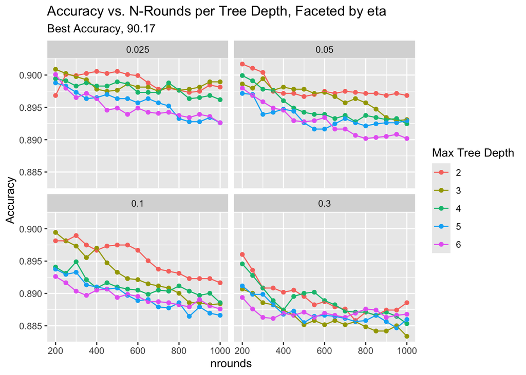

```r
xgb$results |>
    ggplot(aes(nrounds, Accuracy, color = factor(max_depth))) +
    geom_point() +
    geom_line() +
    facet_wrap(~eta) +
    labs(color = 'Max Tree Depth') +
    ggtitle(
        'Accuracy vs. N-Rounds per Tree Depth, Faceted by eta',
        subtitle = sprintf('Best Accuracy, %.2f', max(xgb$results$Accuracy)*100)
    )
```

Best accuracy above should align with `bestTune`:

```r
xgb$bestTune |>
    as_tibble() |>
    kable(caption = sprintf('Accuracy %%%.2f', max(xgb$results$Accuracy)*100)) |>
    kable_styling(bootstrap_options = 'bordered')
```

Accuracy %90.17

| nrounds | max_depth | eta | gamma | colsample_bytree | min_child_weight | subsample |
| --- | --- | --- | --- | --- | --- | --- |
| 200 | 2 | 0.05 | 0 | 1 | 1 | 1 |

Here I lock in the “best” `eta`; continue flexing on `max_depth`; and add variability for `min_child_weight`.

```r
eta   <- xgb$bestTune$eta
shush <- capture.output({
    xgb <- caret::train(
        fc,
        method     = 'xgbTree',
        data       = train_df,
        trControl  = trainControl(
                        method = 'cv',
                        number = 3
                    ),
        tuneGrid   = expand.grid(
            nrounds          = seq(200, 1000, 50),
            eta              = eta,
            max_depth        = 2:5,
            min_child_weight = 1:4,
            colsample_bytree = 1,
            subsample        = 1,
            gamma            = 0
        )
    )
})
```

Here, I plot accuracy per `min_child_weight` versus `nrounds`, faceted by `max_depth`.

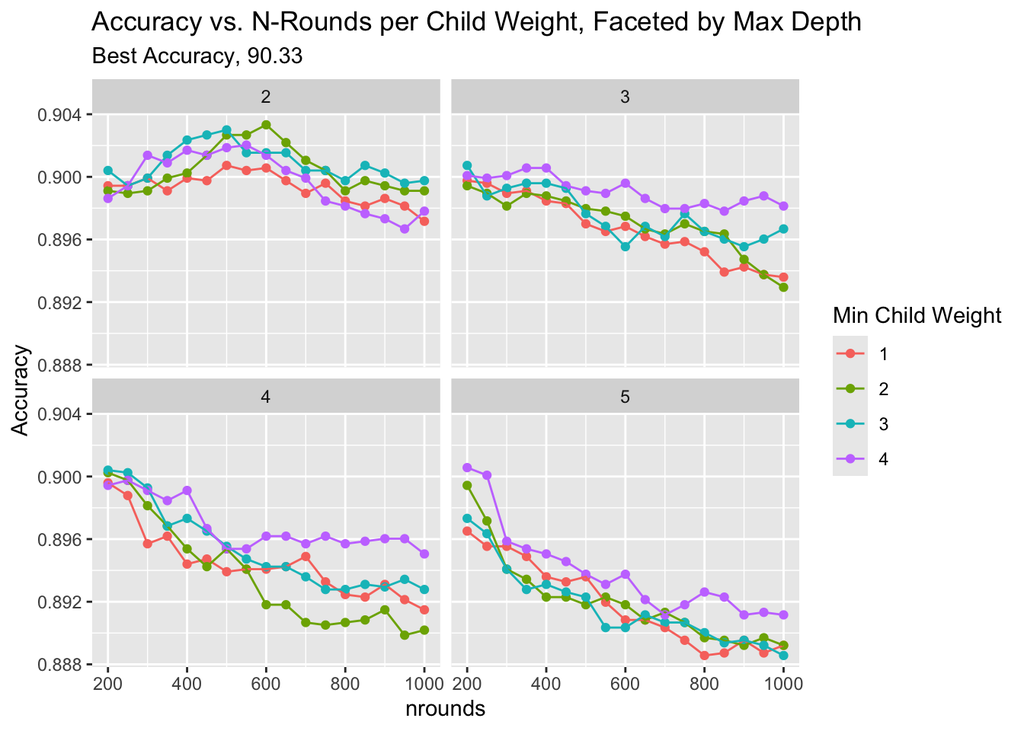

```r
xgb$results |>
    ggplot(aes(nrounds, Accuracy, color = factor(min_child_weight))) +
    geom_point() +
    geom_line() +
    facet_wrap(~max_depth) +
    labs(color = 'Min Child Weight') +
    ggtitle(
        'Accuracy vs. N-Rounds per Child Weight, Faceted by Max Depth',
        subtitle = sprintf('Best Accuracy, %.2f', max(xgb$results$Accuracy)*100)
    )
```

And inspect `bestTune`:

```r
xgb$bestTune |>
    as_tibble() |>
    kable(caption = sprintf('Accuracy %%%.2f', max(xgb$results$Accuracy)*100)) |>
    kable_styling(bootstrap_options = 'bordered')
```

Accuracy %90.33

| nrounds | max_depth | eta | gamma | colsample_bytree | min_child_weight | subsample |
| --- | --- | --- | --- | --- | --- | --- |
| 600 | 2 | 0.05 | 0 | 1 | 2 | 1 |

```r
max_depth        <- xgb$bestTune$max_depth
min_child_weight <- xgb$bestTune$min_child_weight

shush <- capture.output({
    xgb <- caret::train(
        fc,
        method     = 'xgbTree',
        data       = train_df,
        trControl  = trainControl(
                        method = 'cv',
                        number = 3
                    ),
        tuneGrid   = expand.grid(
            nrounds          = seq(200, 1000, 50),
            eta              = eta,
            max_depth        = max_depth,
            min_child_weight = min_child_weight,
            colsample_bytree = seq(.4, 1, .2),
            subsample        = seq(.2, 1, .2),
            gamma            = 0
        )
    )
})
```

And here, I plot accuracy per `subsample` versus `nrounds`, faceted by `colsample_bytree`.

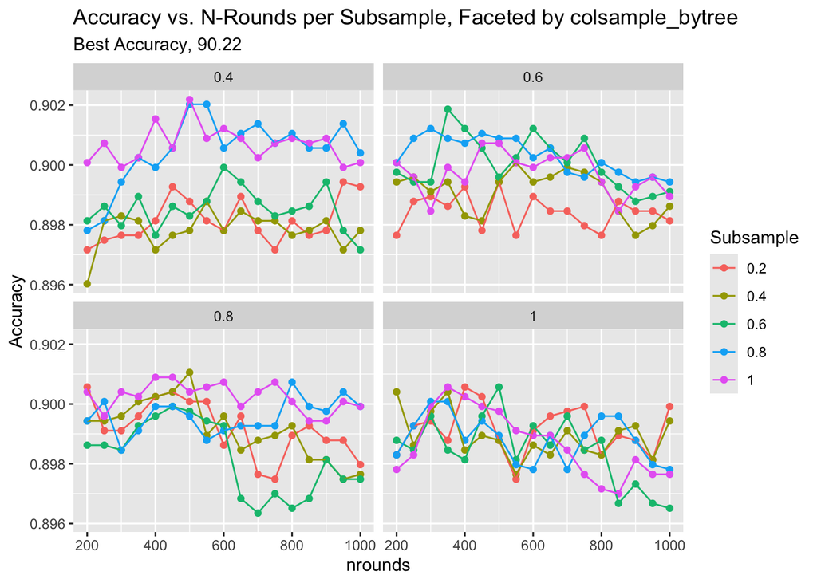

```r
xgb$results |>
    ggplot(aes(nrounds, Accuracy, color = factor(subsample))) +
    geom_point() +
    geom_line() +
    facet_wrap(~colsample_bytree) +
    labs(color = 'Subsample') +
    ggtitle(
        'Accuracy vs. N-Rounds per Subsample, Faceted by colsample_bytree',
         subtitle = sprintf('Best Accuracy, %.2f', max(xgb$results$Accuracy)*100)
)
```

And inspect `bestTune`:

```r
xgb$bestTune |>
    as_tibble() |>
    kable(caption = sprintf('Accuracy %%%.2f', max(xgb$results$Accuracy)*100)) |>
    kable_styling(bootstrap_options = 'bordered')
```

Accuracy %90.22

| nrounds | max_depth | eta | gamma | colsample_bytree | min_child_weight | subsample |
| --- | --- | --- | --- | --- | --- | --- |
| 500 | 2 | 0.05 | 0 | 0.4 | 2 | 1 |

Here I lock in the “best” `colsample_bytree` and `subsample`, and create a sequence for `gamma`.

```r
colsample_bytree <- xgb$bestTune$colsample_bytree
subsample        <- xgb$bestTune$subsample

shush <- capture.output({
    xgb <- caret::train(
        fc,
        method     = 'xgbTree',
        data       = train_df,
        trControl  = trainControl(
                        method = 'cv',
                        number = 3
                    ),
        tuneGrid   = expand.grid(
            nrounds          = seq(200, 1000, 50),
            eta              = eta,
            max_depth        = max_depth,
            min_child_weight = min_child_weight,
            colsample_bytree = colsample_bytree,
            subsample        = subsample,
            gamma            = seq(0, 1, .1)
        )
    )
})
```

And plot accuracy per `gamma` versus `nrounds`.

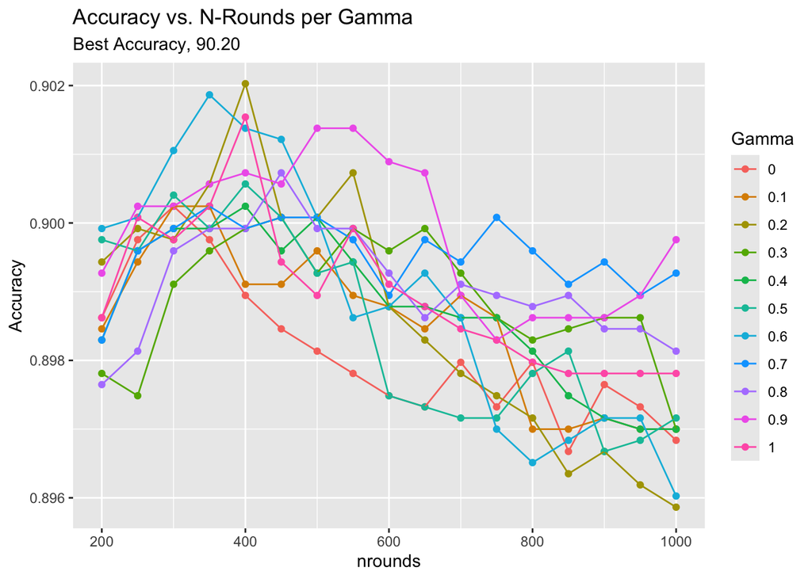

```r
xgb$results |>
    ggplot(aes(nrounds, Accuracy, color = factor(gamma))) +
    geom_point() +
    geom_line() +
    labs(color = 'Gamma') +
    ggtitle(
        'Accuracy vs. N-Rounds per Gamma',
         subtitle = sprintf('Best Accuracy, %.2f', max(xgb$results$Accuracy)*100)
)
```

Inspect `bestTune`:

```r
xgb$bestTune |>
    as_tibble() |>
    kable(caption = sprintf('Accuracy %%%.2f', max(xgb$results$Accuracy)*100)) |>
    kable_styling(bootstrap_options = 'bordered')
```

Accuracy %90.20

| nrounds | max_depth | eta | gamma | colsample_bytree | min_child_weight | subsample |
| --- | --- | --- | --- | --- | --- | --- |
| 400 | 2 | 0.05 | 0.2 | 0.4 | 2 | 1 |

```r
gamma <- xgb$bestTune$gamma

shush <- capture.output({
    xgb <- caret::train(
        fc,
        method     = 'xgbTree',
        data       = train_df,
        trControl  = trainControl(method = 'optimism_boot'),
        tuneGrid   = expand.grid(
            nrounds          = seq(200, 1000, 50),
            eta              = eta,
            max_depth        = max_depth,
            min_child_weight = min_child_weight,
            colsample_bytree = colsample_bytree,
            subsample        = subsample,
            gamma            = gamma
        ),
        preProcess = c('YeoJohnson')
    )
})
```

Inspect `bestTune` and resulting accuracy:

```r
xgb$bestTune |>
    as_tibble() |>
    kable(caption = sprintf('Accuracy %%%.2f', max(xgb$results$Accuracy)*100)) |>
    kable_styling(bootstrap_options = 'bordered')
```

Accuracy %90.40

| nrounds | max_depth | eta | gamma | colsample_bytree | min_child_weight | subsample |
| --- | --- | --- | --- | --- | --- | --- |
| 1000 | 2 | 0.05 | 0.2 | 0.4 | 2 | 1 |

```r
nrounds <- xgb$bestTune$nrounds
eta     <- xgb$bestTune$eta

shush <- capture.output({
    xgb <- caret::train(
        fc,
        method     = 'xgbTree',
        data       = train_df,
        trControl  = trainControl(
            method         = 'optimism_boot',
            preProcOptions = list(thresh = .99)
        ),
        tuneGrid   = expand.grid(
            nrounds          = nrounds,
            eta              = eta,
            max_depth        = max_depth,
            min_child_weight = min_child_weight,
            colsample_bytree = colsample_bytree,
            subsample        = subsample,
            gamma            = gamma
        ),
        preProcess = c('YeoJohnson', 'pca')
    )
})

xgb$bestTune |>
    as_tibble() |>
    kable(caption = sprintf('Accuracy %%%.2f', max(xgb$results$Accuracy)*100)) |>
    kable_styling(bootstrap_options = 'bordered')
```

Accuracy %89.29

| nrounds | max_depth | eta | gamma | colsample_bytree | min_child_weight | subsample |
| --- | --- | --- | --- | --- | --- | --- |
| 1000 | 2 | 0.05 | 0.2 | 0.4 | 2 | 1 |

# 8 Decision Tree

I like to finish with a glimpse at a decision tree, for a sense of the inner mechanics.

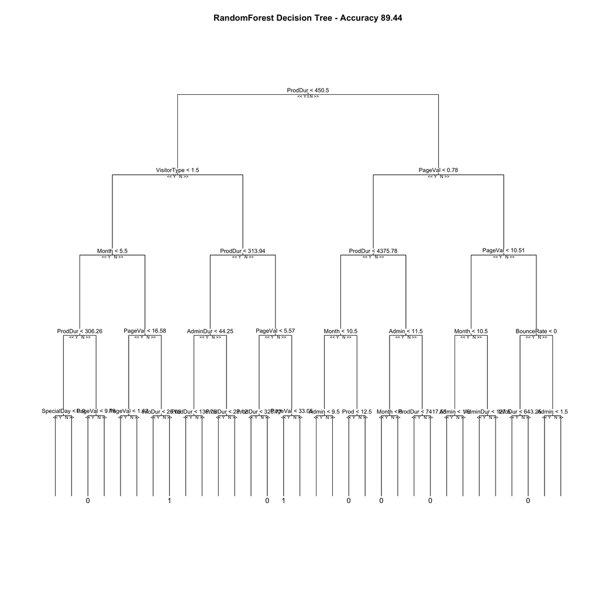

```r
fit                   <- randomForest(Revenue ~ ., train_df, ntree = 20)
simplest_tree         <- which.min(fit$forest$ndbigtree)
fit$forest$xbestsplit <- round(fit$forest$xbestsplit, 2)  # 'digits' workaround
plot.getTree(
    fit,
    k     = simplest_tree,
    depth = 6,
    main  = sprintf(
         'RandomForest Decision Tree - Accuracy %.2f',
         accuracy(fit, test_df)
    )
)
```

# 9 Conclusions

Again, my primary goal was continued learning. I used `t` to rotate `bestTune` objects, after pondering `pivot_wider` and `pivot_longer`; discovered `capture.output` to silence unwanted messages; had my first opportunity since classwork to look at `dist` (for other projects, it ran out of memory or simply seemed inapplicable); and realized my error of assuming `scale=TRUE` for `prcomp`.

Once again though, while I am able to fairly quickly identify one good model from many, I seem unable to make measurable improvements with `preProcess`, `trainControl`, `tuneGrid`, imputing outliers, reducing dimensions, or other attempts.

In this case, I *pause* with a working model; disappointed that it is merely 5% better than guessing, and frustrated that I could not overcome the class imbalance.

# 10 References

https://www.kaggle.com/code/pelkoja/visual-xgboost-tuning-with-caret

https://rafalab.dfci.harvard.edu/dsbook-part-2/highdim/dimension-reduction.html